# Quasiquotation

# 1 Quasiquotation

There are two sides to quasiquotation:

- Quotation allows you to capture the AST associated with an argument. As a function author, this gives you a lot of power to influence how expressions are evaluated.
- Unquotation allows you to selectively evaluate parts of a quoted expression. This is a powerful tool that makes it easy to build up a complex AST from simpler fragments.

## 1.1 Example

Imagine you’re creating a lot of strings by joining together words:

```r
paste("Good", "morning", "Hadley")
```

```
## [1] "Good morning Hadley"
```

```r
paste("Good", "afternoon", "Alice")
```

```
## [1] "Good afternoon Alice"
```

You are sick and tired of writing all those quotes, and instead you just want to use bare words. To that end, you’ve managed to write the following function:

```r
cement <- function(...) {
    dots <- exprs(...)
    paste(purrr::map(dots, expr_name), collapse = " ")
}

cement(Good, morning, Hadley)
```

```
## [1] "Good morning Hadley"
```

```r
cement(Good, afternoon, Alice)
```

```
## [1] "Good afternoon Alice"
```

Formally, this function quotes the arguments in `...`. You can think of it as automatically putting quotation marks around each argument. That’s not precisely true as the intermediate objects it generates are expressions, not strings, but it’s a useful approximation for now.

This function is nice because we no longer need to type quotes. The problem, however, comes when we want to use variables. It’s easy to use variables with `paste()` as we just don’t surround them with quotes:

```r
name <- "Hadley"
time <- "morning"

paste("Good", time, name)
```

```
## [1] "Good morning Hadley"
```

Obviously this doesn’t work with `cement()` because every input is automatically quoted:

```r
cement(Good, time, name)
```

```
## [1] "Good time name"
```

We need some way to explicitly unquote the input, to tell `cement()` to remove the automatic quote marks. Here we need time and name to be treated differently to Good. Quasiquotation give us a standard tool to do so: `!!`, called “unquote”, and pronounced bang-bang. `!!` tells a quoting function to drop the implicit quotes:

```r
cement(Good, !!time, !!name)
```

```
## [1] "Good morning Hadley"
```

It’s useful to compare `cement()` and `paste()` directly. `paste()` evaluates its arguments, so we need to quote where needed; `cement()` quotes its arguments, so we need to unquote where needed.

```r
paste("Good", time, name)
```

```
## [1] "Good morning Hadley"
```

```r
cement(Good, !!time, !!name)
```

```
## [1] "Good morning Hadley"
```

### 1.1.1 Other

```r
name <- "tom"
time <- "morning"

dots <- exprs(Good, morning, tom)
typeof(dots[[2]])
```

```
## [1] "symbol"
```

```r
paste(purrr::map(dots, expr_name), collapse = " ")
```

```
## [1] "Good morning tom"
```

```r
dots <- exprs(Good, time, name)
typeof(dots[[2]])
```

```
## [1] "symbol"
```

```r
paste(purrr::map(dots, expr_name), collapse = " ")
```

```
## [1] "Good time name"
```

```r
dots <- exprs(Good, !!time, !!name)
typeof(dots[[2]])
```

```
## [1] "character"
```

```r
paste(purrr::map(dots, expr_name), collapse = " ")
```

```
## [1] "Good morning tom"
```

```r
time <- 33
dots <- exprs(Good, !!time, !!name)
typeof(dots[[2]])
```

```
## [1] "double"
```

```r
paste(purrr::map(dots, expr_name), collapse = " ")
```

```
## [1] "Good 33 tom"
```

## 1.2 Vocabulary

The distinction between quoted and evaluated arguments is important:

- An evaluated argument obeys R’s usual evaluation rules.
- A quoted argument is captured by the function and something unusual will happen.

If you’re even unsure about whether an argument is quoted or evaluated, try executing the code outside of the function. If it doesn’t work, then that argument is quoted. For example, you can use this technique to determine that the first argument to `library()` is quoted:

```r
# works
library(MASS)

# fails
MASS
```

Talking about whether an argument is quoted or evaluated is a more precise way of stating whether or not a function uses NSE.

### 1.2.1 Exercises

1. For each function in the following base R code, identify which arguments are quoted and which are evaluated.

   ```r
   library(MASS)

   mtcars2 <- subset(mtcars, cyl == 4)

   with(mtcars2, sum(vs))
   sum(mtcars2$am)

   rm(mtcars2)
   ```

   **A**:

   ```r
   library(MASS)
   MASS  # error - quoted
   ```

   ```
   ## Error in eval(expr, envir, enclos): object 'MASS' not found
   ```

   ```r
   mtcars2 <- subset(mtcars, cyl == 4)
   mtcars
   ```

   ```
   ##                      mpg cyl  disp  hp drat    wt  qsec vs am gear carb
   ## Mazda RX4           21.0   6 160.0 110 3.90 2.620 16.46  0  1    4    4
   ## Mazda RX4 Wag       21.0   6 160.0 110 3.90 2.875 17.02  0  1    4    4
   ## Datsun 710          22.8   4 108.0  93 3.85 2.320 18.61  1  1    4    1
   ## Hornet 4 Drive      21.4   6 258.0 110 3.08 3.215 19.44  1  0    3    1
   ## Hornet Sportabout   18.7   8 360.0 175 3.15 3.440 17.02  0  0    3    2
   ## Valiant             18.1   6 225.0 105 2.76 3.460 20.22  1  0    3    1
   ## Duster 360          14.3   8 360.0 245 3.21 3.570 15.84  0  0    3    4
   ## Merc 240D           24.4   4 146.7  62 3.69 3.190 20.00  1  0    4    2
   ## Merc 230            22.8   4 140.8  95 3.92 3.150 22.90  1  0    4    2
   ## Merc 280            19.2   6 167.6 123 3.92 3.440 18.30  1  0    4    4
   ## Merc 280C           17.8   6 167.6 123 3.92 3.440 18.90  1  0    4    4
   ## Merc 450SE          16.4   8 275.8 180 3.07 4.070 17.40  0  0    3    3
   ## Merc 450SL          17.3   8 275.8 180 3.07 3.730 17.60  0  0    3    3
   ## Merc 450SLC         15.2   8 275.8 180 3.07 3.780 18.00  0  0    3    3
   ## Cadillac Fleetwood  10.4   8 472.0 205 2.93 5.250 17.98  0  0    3    4
   ## Lincoln Continental 10.4   8 460.0 215 3.00 5.424 17.82  0  0    3    4
   ## Chrysler Imperial   14.7   8 440.0 230 3.23 5.345 17.42  0  0    3    4
   ## Fiat 128            32.4   4  78.7  66 4.08 2.200 19.47  1  1    4    1
   ## Honda Civic         30.4   4  75.7  52 4.93 1.615 18.52  1  1    4    2
   ## Toyota Corolla      33.9   4  71.1  65 4.22 1.835 19.90  1  1    4    1
   ## Toyota Corona       21.5   4 120.1  97 3.70 2.465 20.01  1  0    3    1
   ## Dodge Challenger    15.5   8 318.0 150 2.76 3.520 16.87  0  0    3    2
   ## AMC Javelin         15.2   8 304.0 150 3.15 3.435 17.30  0  0    3    2
   ## Camaro Z28          13.3   8 350.0 245 3.73 3.840 15.41  0  0    3    4
   ## Pontiac Firebird    19.2   8 400.0 175 3.08 3.845 17.05  0  0    3    2
   ## Fiat X1-9           27.3   4  79.0  66 4.08 1.935 18.90  1  1    4    1
   ## Porsche 914-2       26.0   4 120.3  91 4.43 2.140 16.70  0  1    5    2
   ## Lotus Europa        30.4   4  95.1 113 3.77 1.513 16.90  1  1    5    2
   ## Ford Pantera L      15.8   8 351.0 264 4.22 3.170 14.50  0  1    5    4
   ## Ferrari Dino        19.7   6 145.0 175 3.62 2.770 15.50  0  1    5    6
   ## Maserati Bora       15.0   8 301.0 335 3.54 3.570 14.60  0  1    5    8
   ## Volvo 142E          21.4   4 121.0 109 4.11 2.780 18.60  1  1    4    2
   ```

   ```r
   cyl  # error - quoted
   ```

   ```
   ## Error in eval(expr, envir, enclos): object 'cyl' not found
   ```

   ```r
   with(mtcars2, sum(vs))
   ```

   ```
   ## [1] 10
   ```

   ```r
   vs  # error - quoted
   ```

   ```
   ## Error in eval(expr, envir, enclos): object 'vs' not found
   ```

   ```r
   sum(mtcars2$am)
   ```

   ```
   ## [1] 8
   ```

   ```r
   mtcars2$am
   ```

   ```
   ##  [1] 1 0 0 1 1 1 0 1 1 1 1
   ```

2. For each function in the following tidyverse code, identify which arguments are quoted and which are evaluated.

   ```r
   library(dplyr)
   library(ggplot2)

   by_cyl <- mtcars %>% group_by(cyl) %>% summarise(mean = mean(mpg))

   ggplot(by_cyl, aes(cyl, mean)) + geom_point()
   ```

   **A**:

   ```r
   by_cyl <- mtcars %>%
     group_by(cyl) %>%  # cyl - quoted
     summarise(mean = mean(mpg)) # mean = mean(mpg) - quoted

   ggplot(by_cyl, aes(cyl, mean)) + geom_point() # cyl, mean - quoted
   ```

## 1.3 Quotation

The first part of quasiquotation is quotation: capturing an AST without evaluating it. There are two components to this: capturing an expression directly, and capturing an expression from a lazily-evaluated function argument.

### 1.3.1 With rlang

For interactive exploration, the most important quoting function is `expr()`. It captures its argument exactly as provided:

```r
expr(x + y)
```

```
## x + y
```

```r
expr(1/2/3)
```

```
## 1/2/3
```

```r
expr(x + y)[[1]]
```

```
## `+`
```

```r
expr(x + y)[[2]]
```

```
## x
```

```r
expr(x + y)[[3]]
```

```
## y
```

`exprs()` is useful interactively to make a list of expressions:

```r
exprs(x = x^2, y = y^3, z = z^4)
```

```
## $x
## x^2
##
## $y
## y^3
##
## $z
## z^4
```

`expr()` is great for interactive exploration, because it captures what you, the developer, typed. It’s not useful inside a function:

```r
f1 <- function(x) expr(x)
f1(a + b + c)
```

```
## x
```

Instead, we need another function: `enexpr()`. This captures what the user supplies to the function by looking at the internal promise object that powers lazy evaluation.

```r
f2 <- function(x) enexpr(x)
f2(a + b + c)
```

```
## a + b + c
```

To capture multiple arguments, use `enexprs()`:

```r
f <- function(...) enexprs(...)
f(x = 1, y = 10 * z)
```

```
## $x
## [1] 1
##
## $y
## 10 * z
```

Note: `exprs()` can return missing arguments, but no`expr()`

```r
val <- exprs(x = )
is_missing(val$x)
```

```
## [1] TRUE
```

```r
val <- expr(x = )
```

```
## Error in expr(x = ): unused argument (alist(x = ))
```

### 1.3.2 With Base R

The base equivalent of `expr()` is `quote()`:

```r
quote(x + y)
```

```
## x + y
```

```r
quote(1/2/3)
```

```
## 1/2/3
```

```r
quote(x + y)[[1]]
```

```
## `+`
```

It is identical to `expr()` except that does not support unquoting, so it is a quoting function, not a quasiquoting function.

The base function closest to `enexpr()` is `substitute()`:

```r
f <- function(x) substitute(x)
f(x + y + z)
```

```
## x + y + z
```

You’ll most often see it used to capture unevaluated arguments; often in concert with `deparse()` to create labels for output. However, `substitute()` also does “substitution”: if you give it an expression, rather than a symbol, it will substitute in values of symbols defined in the current environment.

```r
f <- function(x) substitute(x * 2)
f(a + b + c)
```

```
## (a + b + c) * 2
```

But:

```r
f <- function(x) enexpr(x * 2)
f(a + b + c)
```

```
## Error: `arg` must be a symbol
```

`substitute()` provides a sort of automatic unquoting for any symbol that is bound to a value. However, making use of this behaviour can make for hard to read code, because for example, taken out of context, you can’t tell if the goal of `substitute(x + y)` is to replace `x`, or, `y`, or both. If you do want to use `substitute()` in this way, I recommend that you use the 2nd argument to make it clear that is your goal:

```r
substitute(x * y * z, list(x = 10, y = quote(a + b)))
```

```
## 10 * (a + b) * z
```

The base equivalent to `exprs()` is `alist()`:

```r
alist(x = 1, y = x + 2)
```

```
## $x
## [1] 1
##
## $y
## x + 2
```

```r
exprs(x = 1, y = x + 2)
```

```
## $x
## [1] 1
##
## $y
## x + 2
```

Finally, there is no function in base R that is equivalent to `enexprs()` but you can reproduce its behaviour with `eval(substitute(alist(...)))`.

```r
f <- function(...) enexprs(...)
f(x = 1, y = 10 * z)
```

```
## $x
## [1] 1
##
## $y
## 10 * z
```

```r
f1 <- function(...) eval(substitute(alist(...)))
f1(x = 1, y = 10 * z)
```

```
## $x
## [1] 1
##
## $y
## 10 * z
```

There are two other important base quoting functions that we’ll cover elsewhere:

- `bquote()` provides a limited form of quasiquotation, and is discussed in unquoting with base R.
- `~`, the formula, is a quoting function that also captures the environment. It’s the inspiration for quosures, the topic of the next chapter.

### 1.3.3 More substitute

When run from the global environment, it never does substitutions: in fact, in this situation it behaves just like `quote()`:

```r
a <- 1
b <- 2
substitute(a + b + z)
```

```
## a + b + z
```

However, if you run it inside a function, `substitute()` does substitute and leaves everything else as is:

```r
f <- function() {
    a <- 1
    b <- 2
    substitute(a + b + z)
}

f()
```

```
## 1 + 2 + z
```

To make it easier to experiment with `substitute()`, pryr provides the `subs()` function. It works exactly the same way as `substitute()` except it has a shorter name and it works in the global environment. These two features make experimentation easier:

```r
a <- 1
b <- 2
subs(a + b + z)
```

```
## 1 + 2 + z
```

```r
# Also
expr(!!a + !!b + z)
```

```
## 1 + 2 + z
```

Formally, substitution takes place by examining all the names in the expression. If the name refers to:

- an ordinary variable, it’s replaced by the value of the variable.
- a promise (a function argument), it’s replaced by the expression associated with the promise.
- `...`, it’s replaced by the contents of `...`.

Otherwise it’s left as is.

A useful technique:

```r
dots <- function(...) {
    eval(substitute(alist(...)))
}
```

This uses the `alist()` function which simply captures all its arguments. This function is the same as `pryr::dots()`. Pryr also provides `pryr::named_dots()`, which, by using deparsed expressions as default names, ensures that all arguments are named (just like `data.frame()`).

```r
pryr::dots(1, y = 10 * z)
```

```
## [[1]]
## [1] 1
##
## $y
## 10 * z
```

```r
pryr::named_dots(1, y = 10 * z)
```

```
## $`1`
## [1] 1
##
## $y
## 10 * z
```

### 1.3.4 Exercises

1. What happens if you try to use `enexpr()` with an expression? What happens if you try to use `enexpr()` with a missing argument?  
   **A**:

   ```r
   f <- function(x) enexpr(x)

   f(expr(x))  # return expr(x), a call
   ```

   ```
   ## expr(x)
   ```

   ```r
   class(f(expr(x)))
   ```

   ```
   ## [1] "call"
   ```

   ```r
   f()  # returns the missing arg
   ```

   ```r
   is_missing(f())
   ```

   ```
   ## [1] TRUE
   ```

2. Compare and contrast the following two functions. Can you predict the output before running them?

   ```r
   f1 <- function(x, y) {
       exprs(x = x, y = y)
   }
   f2 <- function(x, y) {
       enexprs(x = x, y = y)
   }
   f1(a + b, c + d)
   ```

   ```
   ## $x
   ## x
   ##
   ## $y
   ## y
   ```

   ```r
   f2(a + b, c + d)
   ```

   ```
   ## $x
   ## a + b
   ##
   ## $y
   ## c + d
   ```

   **A**: Both return a named list of expressions. `f1()` will return the arguments supplied to `exprs()` within the body of `f1()`. `f2()` will return the arguments supplied to `f2()`.
3. How are `exprs(a)` and `exprs(a = )` different? Think about both the input and the output.  
   **A**: `exprs(a)` returns an unamed list of one element, the symbol `a`. `exprs(a = )` return a list of one element, the missing argument, named `a`.

   ```r
   exprs(a)
   ```

   ```
   ## [[1]]
   ## a
   ```

   ```r
   exprs(a = )
   ```

4. What does the following command return? What information is lost? Why?

   ```r
   expr({
       x + y  # comment
   })
   ```

   ```
   ## {
   ##     x + y
   ## }
   ```

   **A**: Whitespace and comments are not retained. However, you can get the source information from the attributes of the expresssion.

   ```r
   attributes(expr({
       x + y  # comment
   }))
   ```

   ```
   ## $srcref
   ## $srcref[[1]]
   ## {
   ##
   ## $srcref[[2]]
   ## x + y
   ##
   ##
   ## $srcfile
   ## <text>
   ##
   ## $wholeSrcref
   ## attributes(expr({
   ##     x + y  # comment
   ## }
   ```

5. The documentation for `substitute()` says:

   *Substitution takes place by examining each component of the parse tree as follows: If it is not a bound symbol in env, it is unchanged. If it is a promise object, i.e., a formal argument to a function or explicitly created using* `delayedAssign()`*, the expression slot of the promise replaces the symbol. If it is an ordinary variable, its value is substituted, unless env is* `.GlobalEnv` *in which case the symbol is left unchanged.*

   Create four examples that illustrate each of the different cases. **A**: If it is not a bound symbol in env, it is unchanged

   ```r
   substitute(x, list(y = 1))
   ```

   ```
   ## x
   ```

   If it is a promise object as a formal argument to a function, the expression slot of the promise replaces the symbol.

   ```r
   f <- function(x) substitute(x)
   f(y)  # y
   ```

   ```
   ## y
   ```

   ```r
   # BUT NOTE:
   f <- function(x) {
       x <- 1
       substitute(x)
   }
   f(y)  # 1 - env defaults to current evaluation environment
   ```

   ```
   ## [1] 1
   ```

   ```r
   f <- function(x) {
       substitute(x, list(NULL))
   }
   f(y)  # x - env defaults evaluation environment with no bound symbols
   ```

   ```
   ## x
   ```

   If it is a promise object explicitly created using `delayedAssign()`, the expression slot of the promise replaces the symbol.

   ```r
   y <- 1
   delayedAssign("x", y)
   substitute(x)  # shows only 'x', as it is in the global env.
   ```

   ```
   ## x
   ```

   ```r
   x  # 1
   ```

   ```
   ## [1] 1
   ```

   ```r
   rm(x)

   e <- new.env()
   e$z <- 1
   delayedAssign("x", z, eval.env = e, assign.env = e)
   e$x  # 1
   ```

   ```
   ## [1] 1
   ```

   ```r
   substitute(x, e)  # shows z
   ```

   ```
   ## z
   ```

   ```r
   eval(substitute(x, e), e)  # 1
   ```

   ```
   ## [1] 1
   ```

   If it is an ordinary variable, its value is substituted, unless env is `.GlobalEnv` in which case the symbol is left unchanged.

   ```r
   substitute(x, list(x = 1))  # x is substituted
   ```

   ```
   ## [1] 1
   ```

   ```r
   e <- new.env()
   e$x <- 1
   substitute(x, e)  # x is substituted
   ```

   ```
   ## [1] 1
   ```

   ```r
   x <- 1
   substitute(x, .GlobalEnv)  # x is not substituted
   ```

   ```
   ## x
   ```

## 1.4 Evaluation

Typically you have quoted a function argument for one of two reasons:

- You want to operate on the AST using the techniques described in the previous chapter.
- You want to run, or evaluate the code in a special context, as described in depth next chapter.

Evaluation is a rich topic, so we’ll cover it in depth in the next chapter. Here I’ll just illustrate the most important ideas. The most important base R function is `base::eval()`. Its first argument is the expression to evalute:

```r
ru5 <- expr(runif(5))
ru5
```

```
## runif(5)
```

```r
eval(ru5)
```

```
## [1] 0.2840537 0.7558200 0.9579054 0.9540987 0.3936610
```

```r
eval(ru5)
```

```
## [1] 0.004300733 0.856285784 0.180474862 0.557238857 0.720874696
```

Note that every time we evaluate this expression we get a different result.

The second argument to `eval()` is the environment in which the expression is evaluated. Manipulating this environment gives us amazing power to control the execution of R code.

```r
x <- 9
fx <- expr(f(x))

eval(fx, env(f = function(x) x * 10))
```

```
## [1] 90
```

```r
eval(fx, env(f = function(x) x^2))
```

```
## [1] 81
```

```r
eval(fx, env(f = function(x) {
    print(env_parent())
    x * 10
}))
```

```
## <environment: R_GlobalEnv>
```

```
## [1] 90
```

```r
# parent of function evaluation is Global Env, hence can find x env()
# creates a child of the current environment by default and takes a variable
# number of named objects to populate it.
```

## 1.5 Unquotation

Evaluation is a developer tool: in combination with quoting, it allows the author of a function to capture an argument and evaluate it in a special way. Unquoting is related to evaluation, but it’s a user tool: it allows the person calling the function to selectively evaluate parts of the expression that would otherwise be quoted.

### 1.5.1 With rlang

All quoting functions in rlang (`expr()`, `enexpr()`, and friends) support unquoting with `!!` (called “unquote”, and pronounced bang-bang) and `!!!` (called “unquote-splice”, and pronounced bang-bang-bang). They both replace nodes in the AST. `!!` is a one-to-one replacement. It takes a single expression and inlines the AST at the location of the `!!`.

```r
x <- expr(a + b + c)
expr(f(!!x, y))
```

```
## f(a + b + c, y)
```

```r
expr(f(x, y))
```

```
## f(x, y)
```

```r
lobstr::ast(f(!!x, y))
```

```
## o-f
## +-o-`+`
## | +-o-`+`
## | | +-a
## | | \-b
## | \-c
## \-y
```

```r
lobstr::ast(f(x, y))
```

```
## o-f
## +-x
## \-y
```

`!!!` is a one-to-many replacement. It takes a list of expressions and inserts them at the location of the `!!!`:

```r
x <- exprs(1, 2, 3, y = 10)
expr(f(!!!x, z = z))
```

```
## f(1, 2, 3, y = 10, z = z)
```

```r
lobstr::ast(f(!!!x, z = z))
```

```
## o-f
## +-1
## +-2
## +-3
## +-y = 10
## \-z = z
```

### 1.5.2 The polite fiction of `!!`

So far we have acted as if `!!` and `!!!` are regular prefix operators like `+` , `-`, and `!`. They’re not. Instead, from R’s perspective, `!!` and `!!!` are simply the repeated application of `!`:

```r
!!TRUE  # TRUE
```

```
## [1] TRUE
```

```r
!!!TRUE  # FALSE
```

```
## [1] FALSE
```

`!!` and `!!!` have special behaviour inside all quoting functions powered by rlang, and the unquoting operators are given precedence similar to `+` and `-`, not `!`. We do this because the operator precedence for `!` is surprisingly low: it has lower precedence than that of the binary algebraic and logical operators. Most of the time this doesn’t matter as it is unusual to mix `!` and binary operators (e.g. you typically would not write `!x + y` or `!x > y`). However, expressions like `!!x + !!y` are not uncommon when unquoting, and requiring explicit parentheses, `(!!x) + (!!y)`, feels onerous. For this reason, rlang manipulates the AST to give the unquoting operators a higher, more natural, precedence. (And if for some reason you do need to doubly negate a value in a quasiquoting function, you can just add parentheses `!(!x)`.)

The biggest downside to using a fake operator is that you might get silent errors when misusing `!!` outside of quasiquoting functions. Most of the time this is not an issue because `!!` is typically used to unquote expressions or quosures. Since expressions are not supported by the negation operator, you will get an argument type error in this case:

```r
x <- quote(variable)
!!x
```

```
## Error in !x: invalid argument type
```

```r
y <- expr(variable)
!!y
```

```
## Error in !y: invalid argument type
```

However be extra careful when unquoting numeric values that can be negated silently:

```r
x <- 100
with(mtcars, cyl + !!x)
```

```
##  [1] 7 7 5 7 9 7 9 5 5 7 7 9 9 9 9 9 9 5 5 5 5 9 9 9 9 5 5 5 9 7 9 5
```

```r
with(mtcars, cyl)
```

```
##  [1] 6 6 4 6 8 6 8 4 4 6 6 8 8 8 8 8 8 4 4 4 4 8 8 8 8 4 4 4 8 6 8 4
```

Instead of adding the value of `x` to `cyl` as intended, we have in fact added the double negation of `x`:

```r
!x
```

```
## [1] FALSE
```

```r
!!x
```

```
## [1] TRUE
```

### 1.5.3 With Base R

Base R has one function that implements quasiquotation: `bquote()`. It uses `.()` for unquoting:

```r
xyz <- bquote((x + y + z))
bquote(-.(xyz)/2)
```

```
## -(x + y + z)/2
```

```r
# Also
substitute(-XYZ/2, list(XYZ = xyz))
```

```
## -(x + y + z)/2
```

`bquote()` is a neat function, but is not used by any other function in base R. Instead functions that quote an argument use some other technique to allow indirect specification. There are four basic forms seen in base R:

1. A pair of quoting and non-quoting functions. For example, `$` has two arguments, and the second argument is quoted. This is easier to see if you write in prefix form: `mtcars$cyl` is equivalent to `$(mtcars, cyl)`. If you want to refer to a variable indirectly, you use `[[`, as it takes the name of a variable as a string.

   ```r
   x <- list(var = 1, y = 2)
   var <- "y"

   x$var  # 1
   ```

   ```
   ## [1] 1
   ```

   ```r
   x[[var]]  # 2
   ```

   ```
   ## [1] 2
   ```

   `<-/assign()` work similarly:

   ```r
   y <- 1
   x <- y
   x
   ```

   ```
   ## [1] 1
   ```

   ```r
   var <- "x"
   assign(var, 3)
   x
   ```

   ```
   ## [1] 3
   ```

   ```r
   # note
   z <- 3
   "x" <- z
   x
   ```

   ```
   ## [1] 3
   ```

2. A pair of quoting and non-quoting arguments. For example, `data()`, `rm()`, and `save()` allow you to provide bare variable names in `...`, or a character vector of variable names in `list`:

   ```r
   x <- 1
   rm(x)

   y <- 2
   vars <- c("y", "vars")
   rm(list = vars)
   ```

3. An argument that controls whether a different argument is quoting or non-quoting. For example, in `library()`, the character.only argument controls the quoting behaviour of of the first argument, package:

   ```r
   library(MASS)

   pkg <- "MASS"
   library(pkg, character.only = TRUE)
   ```

   `demo()`, `detach()`, `example()`, and `require()` work similarly.
4. Quoting if evaluation fails. For example, the first argument to `help()` is non-quoting if it evaluates to a string; if evaluation fails, the first argument is quoted.

   ```r
   # Shows help for var
   help(var)

   var <- "mean"
   # Shows help for mean
   help(var)

   var <- 10
   # Shows help for var
   help(var)
   ```

   `ls()`, `page()`, and `match.fun()` work similarly.

Some quoting functions, like `subset()`, `transform()`, and `with()`, don’t have a non-quoting form. This is because they are seen as wrappers around `[` and `[<-` that are only suitable for interactive use.

### 1.5.4 Missing arguments

Occasionally it is useful to unquote a missing argument, but the naive approach doesn’t work:

```r
arg <- missing_arg()
expr(foo(!!arg, !!arg))
```

```
## Error in enexpr(expr): argument "arg" is missing, with no default
```

You can either wrap in a list and use unquote-splice, or use the `maybe_missing()` helper:

```r
args <- list(missing_arg(), missing_arg())
expr(foo(!!!args))
```

```
## foo(, )
```

```r
expr(foo(!!maybe_missing(arg), !!maybe_missing(arg)))
```

```
## foo(, )
```

### 1.5.5 Exercises

1. Given the following components:

   ```r
   xy <- expr(x + y)
   xz <- expr(x + z)
   yz <- expr(y + z)
   abc <- exprs(a, b, c)
   ```

   Use quasiquotation to construct the following calls:

   ```r
   (x + y)/(y + z)
   -(x + z)^(y + z)
   (x + y) + (y + z) - (x + y)
   atan2(x + y, y + z)
   sum(x + y, x + y, y + z)
   sum(a, b, c)
   mean(c(a, b, c), na.rm = TRUE)
   foo(a = x + y, b = y + z)
   ```

   **A**:

   ```r
   expr(!!xy/!!yz)
   ```

   ```
   ## (x + y)/(y + z)
   ```

   ```r
   expr(-(!!xz)^!!yz)
   ```

   ```
   ## -(x + z)^(y + z)
   ```

   ```r
   expr(!!xy + !!yz - !!xy)
   ```

   ```
   ## x + y + (y + z) - (x + y)
   ```

   ```r
   expr(atan2(!!xy, !!yz))
   ```

   ```
   ## atan2(x + y, y + z)
   ```

   ```r
   expr(sum(!!xy, !!xy, !!yz))
   ```

   ```
   ## sum(x + y, x + y, y + z)
   ```

   ```r
   expr(sum(!!!abc))
   ```

   ```
   ## sum(a, b, c)
   ```

   ```r
   expr(sum(!!!abc, na.rm = TRUE))
   ```

   ```
   ## sum(a, b, c, na.rm = TRUE)
   ```

   ```r
   expr(foo(a = !!xy, b = !!yz))
   ```

   ```
   ## foo(a = x + y, b = y + z)
   ```

   ```r
   (a <- expr(mean(1:10)))
   ```

   ```
   ## mean(1:10)
   ```

   ```r
   (b <- expr(mean(!!(1:10))))
   ```

   ```
   ## mean(1:10)
   ```

   ```r
   identical(a, b)
   ```

   ```
   ## [1] FALSE
   ```

   What’s the difference? Which one is more natural?  
   **A**: in the 2nd expression `!!(1:10)` evaluates to a sequence of integers, but this prints as 1:10. In the first expression, `1:10` is a call, `:(1, 10)`.

   ```r
   (a <- expr(mean(1:10)))
   ```

   ```
   ## mean(1:10)
   ```

   ```r
   (b <- expr(mean(!!(1:10))))
   ```

   ```
   ## mean(1:10)
   ```

   ```r
   eval(a)
   ```

   ```
   ## [1] 5.5
   ```

   ```r
   eval(b)
   ```

   ```
   ## [1] 5.5
   ```

   ```r
   a[[1]]
   ```

   ```
   ## mean
   ```

   ```r
   b[[1]]
   ```

   ```
   ## mean
   ```

   ```r
   typeof(a[[1]])  # symbol
   ```

   ```
   ## [1] "symbol"
   ```

   ```r
   typeof(b[[1]])  # symbol
   ```

   ```
   ## [1] "symbol"
   ```

   ```r
   a[[2]]
   ```

   ```
   ## 1:10
   ```

   ```r
   b[[2]]
   ```

   ```
   ##  [1]  1  2  3  4  5  6  7  8  9 10
   ```

   ```r
   typeof(a[[2]])  # language
   ```

   ```
   ## [1] "language"
   ```

   ```r
   typeof(b[[2]])  # integer
   ```

   ```
   ## [1] "integer"
   ```

   ```r
   class(a[[2]])  # call
   ```

   ```
   ## [1] "call"
   ```

   ```r
   class(b[[2]])  # integer
   ```

   ```
   ## [1] "integer"
   ```

   ```r
   lobstr::ast(!!a)
   ```

   ```
   ## o-mean
   ## \-o-`:`
   ##   +-1
   ##   \-10
   ```

   ```r
   lobstr::ast(!!b)
   ```

   ```
   ## o-mean
   ## \-<inline integer>
   ```

## 1.6 Case studies

### 1.6.1 Map-reduce to generate code

Quasiquotation gives us powerful tools for generating code, particularly when combined with `purrr::map()` and `purr::reduce()`. For example, assume you have a linear model specified by the following coefficients:

```r
intercept <- 10
coefs <- c(x1 = 5, x2 = -4)
```

And you want to convert it into an expression like `10 + (5 * x1) + (-4 * x2)`. The first thing we need to do is turn the character names vector into a list of symbols. `rlang::syms()` is designed precisely for this case:

```r
coef_sym <- syms(names(coefs))
coef_sym
```

```
## [[1]]
## x1
##
## [[2]]
## x2
```

Next we need to combine each variable name with its coefficient. We can do this by combining `expr()` with `map2()`:

```r
summands <- map2(coef_sym, coefs, ~expr((!!.x * !!.y)))
summands
```

```
## [[1]]
## (x1 * 5)
##
## [[2]]
## (x2 * -4)
```

In this case, the intercept is also a part of the sum, although it doesn’t involve a multiplication. We can just add it to the start of the summands vector:

```r
summands <- c(intercept, summands)
summands
```

```
## [[1]]
## [1] 10
##
## [[2]]
## (x1 * 5)
##
## [[3]]
## (x2 * -4)
```

Finally, we need to reduce the individual terms in to a single sum by adding the pieces together:

```r
eq <- reduce(summands, ~expr(!!.x + !!.y))
eq
```

```
## 10 + (x1 * 5) + (x2 * -4)
```

Once you have this expression, you could evaluate it with new data, or turn it into a function:

```r
df <- data.frame(x1 = runif(5), x2 = runif(5))
eval(eq, df)
```

```
## [1]  7.418841 10.335059 10.621838 10.122789 10.100385
```

```r
args <- map(coefs, ~missing_arg())
new_function(args, expr({
    !!eq
}))
```

```
## function (x1, x2)
## {
##     10 + (x1 * 5) + (x2 * -4)
## }
```

### 1.6.2 Partition

Imagine that you want to extend `dplyr::select()` to return two data frames: one with the variables you selected, and one with the variables that remain.

here are plenty of ways to attack this problem, but one way is to take advantage of `select()`’s ability to negate column selection expression in order to remove those columns. We can capture the inputs with quasiquotation, then invert each selection call by negating it. We start by practicing interactively with a list of variables created with `exprs()`:

```r
vars <- exprs(x, y, c(a, b), starts_with("x"))
map(vars, ~expr(-!!.x))
```

```
## [[1]]
## -x
##
## [[2]]
## -y
##
## [[3]]
## -c(a, b)
##
## [[4]]
## -starts_with("x")
```

Then turn it into a function:

```r
partition_cols <- function(.data, ...) {
    included <- enexprs(...)
    excluded <- map(included, ~expr(-!!.x))

    list(incl = select(.data, !!!included), excl = select(.data, !!!excluded))
}

df <- data.frame(x1 = 1, x2 = 3, y = "a", z = "b")
partition_cols(df, starts_with("x"))

# > $incl > x1 x2 > 1 1 3 > > $excl > y z > 1 a b
```

### 1.6.3 Slicing an array

One occassionally useful tool that’s missing from base R is the ability to extract a slice of an array given a dimension and an index. For example, we’d like to write `slice(x, 2, 1)` to extract the first slice along the second dimension, which you can write as `x[, 1, ]`.

We’ll need to generated a call will multiple missing arguments. Fortunately is easy with `rep()` and `missing_arg()`. Once we have those arguments, we can unquote-splice them into a call:

```r
(indices <- rep(list(missing_arg()), 3))
```

```r
expr(x[!!!indices])
```

```
## x[, , ]
```

We then wrap this into a function, using subset-assignment to insert the index in the desired position:

```r
slice <- function(x, along, index) {
    stopifnot(length(index) == 1)

    nd <- length(dim(x))
    indices <- rep(list(missing_arg()), nd)
    indices[along] <- index

    expr(x[!!!indices])
}

x <- array(sample(30), c(5, 2, 3))
slice(x, 1, 3)
```

```
## x[3, , ]
```

```r
slice(x, 2, 2)
```

```
## x[, 2, ]
```

```r
slice(x, 3, 1)
```

```
## x[, , 1]
```

A real `slice()` would evaluate the generated call, but here I think it’s more illuminating to see the code that’s generated, as that’s the hard part of the challenge.

### 1.6.4 Creating functions

Another powerful function to use in combination with unquoting is `rlang::new_function()`: it allows us to create a function by supplying the arguments, the body, and (optionally) the environment:

```r
new_function(exprs(x = , y = ), expr({
    x + y
}))
```

```
## function (x, y)
## {
##     x + y
## }
```

One application is to create functions that work like `graphics::curve()`. `curve()` allows you to plot a mathematical expression, without creating a function:

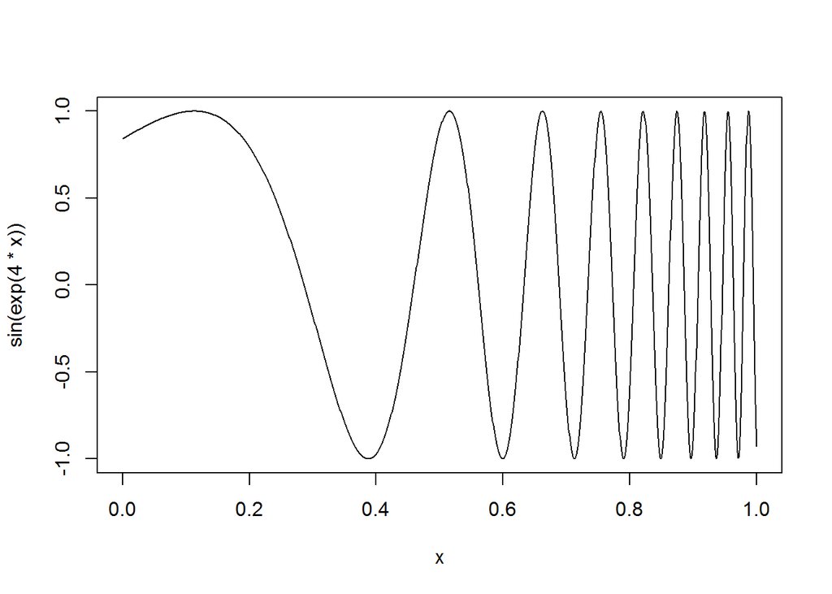

```r
curve(sin(exp(4 * x)), n = 1000)
```

One way to implement `curve()` is to turn the expression into a function with a single argument, then call that function:

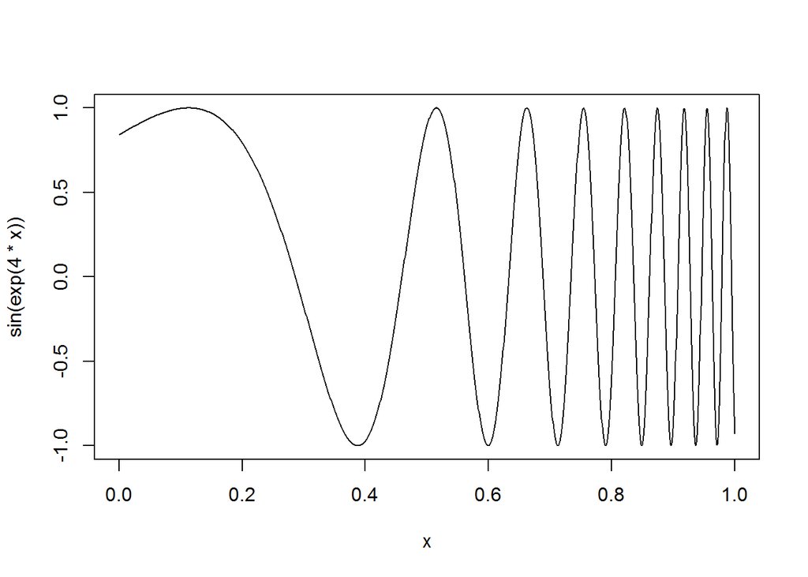

```r
curve2 <- function(expr, xlim = c(0, 1), n = 100) {
    expr <- enexpr(expr)
    f <- new_function(exprs(x = ), expr)

    x <- seq(xlim[1], xlim[2], length = n)
    y <- f(x)

    plot(x, y, type = "l", ylab = expr_text(expr))
}
curve2(sin(exp(4 * x)), n = 1000)
```

Another use for `new_function()` is as an alternative to simple function factories and function operators. The primary advantage is that the generated functions have readable source code:

```r
negate1 <- function(f) {
    force(f)
    function(...) !f(...)
}
negate1(is.null)
```

```
## function(...) !f(...)
## <environment: 0x000000000d5da8b0>
```

```r
negate2 <- function(f) {
    f <- enexpr(f)
    new_function(exprs(... = ), expr(!(!!f)(...)), caller_env())
}
negate2(is.null)
```

```
## function (...)
## !is.null(...)
```

### 1.6.5 Exercises

1. Implement `arrange_desc()`, a variant of `dplyr::arrange()` that sorts in descending order by default.  
   **A**:

   ```r
   arrange_desc <- function(.data, ...) {
       dcols <- map(enexprs(...), ~expr(desc(!!.x)))
       arrange(.data, !!!dcols)
   }

   df <- data.frame(x = c(1, 3, 3), y = c(6, 4, 5), z = c(9, 7, 8))
   arrange_desc(df, x)
   ```

   ```
   ##   x y z
   ## 1 3 4 7
   ## 2 3 5 8
   ## 3 1 6 9
   ```

   ```r
   arrange_desc(df, x, y)
   ```

   ```
   ##   x y z
   ## 1 3 5 8
   ## 2 3 4 7
   ## 3 1 6 9
   ```

2. Implement `filter_or()`, a variant of `dplyr::filter()` that combines multiple arguments using `|` instead of `&`. **A**:

   ```r
   df <- data.frame(x = c(1, 3, 3), y = c(6, 4, 5), z = c(9, 7, 8))
   dplyr::filter(df, x == 3)
   ```

   ```
   ##   x y z
   ## 1 3 4 7
   ## 2 3 5 8
   ```

   ```r
   dplyr::filter(df, x == 3, y == 4)
   ```

   ```
   ##   x y z
   ## 1 3 4 7
   ```

   ```r
   filter_or <- function(.data, ...) {
       included <- enexprs(...)

       eq <- reduce(included, ~expr(!!.x | !!.y))
       dplyr::filter(.data, !!eq)
   }

   filter_or(df, x == 1, y == 4)
   ```

   ```
   ##   x y z
   ## 1 1 6 9
   ## 2 3 4 7
   ```

3. Implement `partition_rows()` which, like `partition_cols()`, returns two data frames, one containing the selected rows, and the other containing the rows that weren’t selected.  
   **A**:

   ```r
   partition_rows <- function(.data, ...) {
       included <- enexprs(...)
       excluded <- map(included, ~expr(!(!!.x)))

       list(incl = filter(.data, !!!included), excl = filter_or(.data, !!!excluded)  # note use of filter_or since!(a & b) = !a | !b
   )
   }

   df <- data.frame(x = c(1, 3, 3), y = c(6, 4, 5), z = c(9, 7, 8))
   partition_rows(df, x == 1)
   ```

   ```
   ## $incl
   ##   x y z
   ## 1 1 6 9
   ##
   ## $excl
   ##   x y z
   ## 1 3 4 7
   ## 2 3 5 8
   ```

   ```r
   partition_rows(df, x == 3, y == 4)
   ```

   ```
   ## $incl
   ##   x y z
   ## 1 3 4 7
   ##
   ## $excl
   ##   x y z
   ## 1 1 6 9
   ## 2 3 5 8
   ```

4. Add error handling to `slice()`. Give clear error messages if either along or index have invalid values (i.e. not numeric, not length 1, too small, or too big).  
   **A**:

   ```r
   slice <- function(x, along, index) {
       if (dim(x) == 0) {
           message("x is empty")
           return(NULL)
       }

       if (!(is.numeric(index) & length(index) == 1))
           stop("index not a numeric of length 1", call. = FALSE)
       if (!(is.numeric(along) & length(along) == 1))
           stop("index not a numeric of length 1", call. = FALSE)

       if (index < 1)
           stop("index is less than 1", call. = FALSE)
       if (along < 1)
           stop("index is less than 1", call. = FALSE)

       nd <- length(dim(x))

       if (along > nd)
           stop("along is greater than number of dimensions", call. = FALSE)
       if (index > dim(x)[along])
           stop("index is greater than size of dimension", call. = FALSE)

       indices <- rep(list(missing_arg()), nd)
       indices[along] <- index

       expr(x[!!!indices])
   }

   x <- array(sample(30), c(5, 2, 3))
   slice(x, 1, 3)
   ```

   ```
   ## x[3, , ]
   ```

   ```r
   slice(x, 1, numeric(0))
   ```

   ```
   ## Error: index not a numeric of length 1
   ```

   ```r
   slice(x, 1, c(3, 2))
   ```

   ```
   ## Error: index not a numeric of length 1
   ```

   ```r
   slice(x, 1, character(0))
   ```

   ```
   ## Error: index not a numeric of length 1
   ```

   ```r
   slice(x, 1, "y")
   ```

   ```
   ## Error: index not a numeric of length 1
   ```

   ```r
   slice(x, 1, -3)
   ```

   ```
   ## Error: index is less than 1
   ```

   ```r
   slice(x, -1, 3)
   ```

   ```
   ## Error: index is less than 1
   ```

   ```r
   slice(x, 4, 3)
   ```

   ```
   ## Error: along is greater than number of dimensions
   ```

   ```r
   slice(x, 1, 6)
   ```

   ```
   ## Error: index is greater than size of dimension
   ```

   ```r
   x <- array(numeric(0))
   dim(x)
   ```

   ```
   ## [1] 0
   ```

   ```r
   slice(x, 1, 3)
   ```

   ```
   ## x is empty
   ```

5. Re-implement the Box-Cox transform defined below using unquoting and `new_function()`:

   ```r
   bc <- function(lambda) {
       if (lambda == 0) {
           function(x) log(x)
       } else {
           function(x) (x^lambda - 1)/lambda
       }
   }
   ```

   **A**:

   ```r
   bc <- function(lambda) {
       if (lambda == 0) {
           function(x) log(x)
       } else {
           function(x) (x^lambda - 1)/lambda
       }
   }
   bc(0)
   ```

   ```
   ## function(x) log(x)
   ## <environment: 0x000000000ad5e938>
   ```

   ```r
   bc(1)
   ```

   ```
   ## function(x) (x^lambda - 1)/lambda
   ## <bytecode: 0x000000000d030e78>
   ## <environment: 0x000000000a6a4820>
   ```

   ```r
   bc(2)
   ```

   ```
   ## function(x) (x^lambda - 1)/lambda
   ## <bytecode: 0x000000000d030e78>
   ## <environment: 0x000000000d0ec4c8>
   ```

   ```r
   bc(4^0.5)
   ```

   ```
   ## function(x) (x^lambda - 1)/lambda
   ## <bytecode: 0x000000000d030e78>
   ## <environment: 0x000000000d187758>
   ```

   ```r
   bc(2)(3)
   ```

   ```
   ## [1] 4
   ```

   ```r
   # reimplemented
   bc2 <- function(lambda) {
       if (lambda == 0) {
           new_function(exprs(x = ), expr(log(x)))
       } else {
           new_function(exprs(x = ), expr((x^(!!lambda) - 1)/!!lambda))
       }
   }
   # note there is no need to capture enexpr(lambda) as we will only evaluate
   # lambda, not access its AST

   bc2(0)
   ```

   ```
   ## function (x)
   ## log(x)
   ## <environment: 0x000000000d3a6608>
   ```

   ```r
   bc2(1)
   ```

   ```
   ## function (x)
   ## (x^1 - 1)/1
   ## <environment: 0x000000000d44ba78>
   ```

   ```r
   bc2(2)
   ```

   ```
   ## function (x)
   ## (x^2 - 1)/2
   ## <environment: 0x000000000dcd2ac8>
   ```

   ```r
   bc2(4^0.5)
   ```

   ```
   ## function (x)
   ## (x^2 - 1)/2
   ## <environment: 0x000000000dd85f08>
   ```

   ```r
   bc2(2)(3)
   ```

   ```
   ## [1] 4
   ```

6. Re-implement the simple `compose()` defined below using quasiquotation and `new_function()`:

   ```r
   compose <- function(f, g) {
       function(...) f(g(...))
   }
   ```

   **A**:

   ```r
   compose <- function(f, g) {
       function(...) f(g(...))
   }
   compose(sin, cos)
   ```

   ```
   ## function(...) f(g(...))
   ## <environment: 0x0000000008ce23a8>
   ```

   ```r
   compose(sin, cos)(pi)
   ```

   ```
   ## [1] -0.841471
   ```

   ```r
   compose2 <- function(f, g) {
       f <- enexpr(f)
       g <- enexpr(g)
       new_function(exprs(... = ), expr((!!f)((!!g)(...))), caller_env())
   }
   compose2(sin, cos)
   ```

   ```
   ## function (...)
   ## sin(cos(...))
   ```

   ```r
   compose2(sin, cos)(pi)
   ```

   ```
   ## [1] -0.841471
   ```

## 1.7 Dot-dot-dot (`...`)

Quasiquotation ensures that every quoted argument has an escape hatch that allows the user to unquote, or evaluate, selected components, if needed. A similar and related need arises with functions that take arbitrary additional arguments with `...`.

Take the following two motivating problems:

What do you do if the elements you want to put in `...` are already stored in a list? For example, imagine you have a list of data frames that you want to `rbind()` together:

```r
dfs <- list(a = data.frame(x = 1, y = 2), b = data.frame(x = 3, y = 4))
```

You could solve this specific case with `rbind(dfs$a, df$b)`, but how do you generalise that solution to a list of arbitrary length?

What do you do if you want to supply the argument name indirectly? For example, imagine you want to create a single column data frame where the name of the column is specified in a variable:

```r
var <- "x"
val <- c(4, 3, 9)
```

In this case, you could create a data frame and then change names (i.e. `setNames(data.frame(val), var)`), but this feels inelegant. How can we do better?

### 1.7.1 `do.call()`

Base R provides a swiss-army knife to solve these problems: `do.call()`. `do.call()` has two main arguments. The first argument, `what`, gives a function to call. The second argument, `args`, is a list of arguments to pass to that function, and so `do.call("f", list(x, y, z))` is equivalent to `f(x, y, z)`.

`do.call()` gives a straightforward solution to `rbind()`ing together many data frames:

```r
do.call("rbind", dfs)
```

```
##   x y
## a 1 2
## b 3 4
```

With a little more work, we can use `do.call()` to solve the second problem. We first create a list of arguments, then name that, then use `do.call()`:

```r
args <- list(val)
names(args) <- var
do.call("data.frame", args)
```

```
##   x
## 1 4
## 2 3
## 3 9
```

### 1.7.2 The tidyverse approach

The tidyverse solves these problems in a different way to base R, by drawing parallel to quasiquotation:

Row-binding multiple data frames is like unquote-splicing: we want to inline individual elements of the list into the call:

```r
dplyr::bind_rows(!!!dfs)
```

```
##   x y
## 1 1 2
## 2 3 4
```

When used in this context, the behaviour of `!!!` is known as spatting in Ruby, Go, PHP, and Julia. It is closely related to `*args` (star-args) and `**kwarg` (star-star-kwargs) in Python, which are sometimes called argument unpacking.

The second problem is like unquoting on the LHS of `=:` rather than interpreting var literaly, we want to use the value stored in the variable called var:

```r
tibble::tibble(!!var := val)
```

```
## # A tibble: 3 x 1
##       x
##   <dbl>
## 1     4
## 2     3
## 3     9
```

Note the use of `:=` (pronounced colon-equals) rather than `=`. Unfortunately we need this new operation because R’s grammar does not allow expressions as argument names:

```r
tibble::tibble(!!var = value)
```

```
## Error: <text>:1:22: unexpected '='
## 1: tibble::tibble(!!var =
##                          ^
```

`:=` is like a vestigial organ: it’s recognised by R’s parser, but it doesn’t have any code associated with it. It looks like an `=` but allows expressions on either side, making it a more flexible alternative to `=`. It is used in data.table for similar reasons.

### 1.7.3 `list2()`

Both `dplyr::bind_rows()` and `tibble::tibble()` are powered by `rlang::list2(...)`. This function is very similar to `list(...)`, but it understands `!!!` and `!!`. If you want to take advantage of this behaviour in your own function, all you need to do is use `list2()` in your own code. For example, imagine you want to make a version of `structure()` that understands `!!!` and `!!`. We’ll call it `set_attr()`:

```r
set_attr <- function(.x, ...) {
    attr <- rlang::list2(...)
    attributes(.x) <- attr
    .x
}

attrs <- list(x = 1, y = 2)
attr_name <- "z"

1:10 %>% set_attr(w = 0, !!!attrs, `:=`(!!attr_name, 3)) %>% str()
```

```
##  int [1:10] 1 2 3 4 5 6 7 8 9 10
##  - attr(*, "w")= num 0
##  - attr(*, "x")= num 1
##  - attr(*, "y")= num 2
##  - attr(*, "z")= num 3
```

### 1.7.4 Other approaches

Apart from `rlang::list2()` there are several other techniques used to overcome the motivating challenges described above. One technique is to take `...` and a single unnamed argument that is a list, making `f(list(x, y, z))` equivalent to `f(x, y, z)`. The implementation looks something like this:

```r
f <- function(...) {
    dots <- list(...)
    if (length(dots) == 1 && is.list(dots[[1]])) {
        dots <- dots[[1]]
    }

    # Do something
    ...
}
```

Base functions that use this technique include `interaction()`, `expand.grid()`, `options()`, and `par()`. Since these functions take either a list or `...`, but not both, they are slightly less flexible than functions powered by `list2()`.

### 1.7.5 Exercises

1. Carefully read the source code for `interaction()`, `expand.grid()`, and `par()`. Compare and contrast the techniques they use for switching between dots and list behaviour. **A**: They all check to see if `...` has one argument that is a list; if so then this list become the de facto arguments. General form is:

   ```r
   f <- function(...) {
       dots <- list(...)
       if (length(dots) == 1 && is.list(dots[[1]])) {
           dots <- dots[[1]]
       }

       # Do something
       ...
   }
   ```

   Specific code is

   ```r
   # interaction
   interaction(..., drop = FALSE, sep = ".", lex.order = FALSE)

   args <- list(...)
   narg <- length(args)
   if (narg < 1L)
       stop("No factors specified")
   if (narg == 1L && is.list(args[[1L]])) {
       args <- args[[1L]]
       narg <- length(args)
   }

   # expand.grid
   expand.grid(..., KEEP.OUT.ATTRS = TRUE, stringsAsFactors = TRUE)

   nargs <- length(args <- list(...))
   if (!nargs)
       return(as.data.frame(list()))
   if (nargs == 1L && is.list(a1 <- args[[1L]]))
       nargs <- length(args <- a1)
   if (nargs == 0L)
       return(as.data.frame(list()))

   # par
   par(..., no.readonly = FALSE)

   args <- list(...)
   if (!length(args))
       args <- as.list(if (no.readonly)
           .Pars[-match(.Pars.readonly, .Pars)]
       else .Pars)
   else {
       if (all(unlist(lapply(args, is.character))))
           args <- as.list(unlist(args))
       if (length(args) == 1) {
           if (is.list(args[[1L]]) | is.null(args[[1L]]))
               args <- args[[1L]]
           else if (is.null(names(args)))
               single <- TRUE
       }
   }
   ```

2. Explain the problem with this definition of `set_attr()`

   ```r
   set_attr <- function(x, ...) {
       attr <- rlang::list2(...)
       attributes(x) <- attr
       x
   }
   set_attr(1:10, x = 10)
   ```

   ```
   ## Error in attributes(x) <- attr: attributes must be named
   ```

   **A**: `x = 10` gets matched to the first argument of `set_attr`. Hence `1:10` is treated as `...` and hence as an attribute to be assigned to `x`. However `1:10` is not named.

   ```r
   # change first argument name to .x
   set_attr <- function(.x, ...) {
       attr <- rlang::list2(...)
       attributes(.x) <- attr
       .x
   }
   set_attr(1:10, x = 10)
   ```

   ```
   ##  [1]  1  2  3  4  5  6  7  8  9 10
   ## attr(,"x")
   ## [1] 10
   ```

   ```r
   # this works but is presumably not what was intended (x has value 10 an
   # attribute y = 1:10)
   set_attr <- function(x, ...) {
       attr <- rlang::list2(...)
       attributes(x) <- attr
       x
   }
   set_attr(y = 1:10, x = 10)
   ```

   ```
   ## [1] 10
   ## attr(,"y")
   ##  [1]  1  2  3  4  5  6  7  8  9 10
   ```